# Machine Learning Lab

## Lab 3 - Seaborn

S Shyam Sundaram  
19BCE1560  
August 16, 2021  
Abdul Quadir Md  
L31+L32

```python
import numpy as np
import matplotlib.pyplot as plt
import seaborn as sb
```

## Inbuilt Datasets

```python
print(sb.get_dataset_names())
```

```
['anagrams', 'anscombe', 'attention', 'brain_networks', 'car_crashes', 'diamonds', 'dots', 'exercise', 'flights', 'fmri', 'gammas', 'geyser', 'iris', 'mpg', 'penguins', 'planets', 'tips', 'titanic']
```

```python
df1 = sb.load_dataset("flights")
df1.info()
df1.head()
```

```
<class 'pandas.core.frame.DataFrame'>
RangeIndex: 144 entries, 0 to 143
Data columns (total 3 columns):
 #   Column      Non-Null Count  Dtype
---  ------      --------------  -----
 0   year        144 non-null    int64
 1   month       144 non-null    category
 2   passengers  144 non-null    int64
dtypes: category(1), int64(2)
memory usage: 2.9 KB
```

|  | year | month | passengers |
| --- | --- | --- | --- |
| 0 | 1949 | Jan | 112 |
| 1 | 1949 | Feb | 118 |
| 2 | 1949 | Mar | 132 |
| 3 | 1949 | Apr | 129 |
| 4 | 1949 | May | 121 |

## Scatter plot

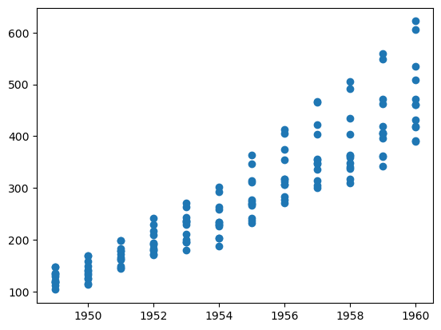

```python
#plt.figure(figsize=(2,2))
plt.scatter(df1['year'],df1['passengers'])
plt.show()
```

Huevector or key in data Grouping variable that will produce elements with different colors. Can be either categorical or numeric, although color mapping will behave differently in latter case.

## Relational Plot

[figure not shown]

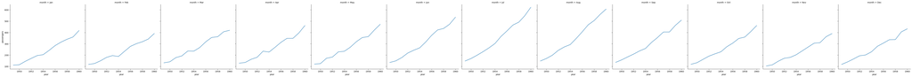

```python
sb.relplot(x="year",y="passengers",data=df1,kind="line",col="month")
plt.show()
```

## Heatmap

```
[[4 1 0 0 1]
 [1 0 3 2 2]]
```

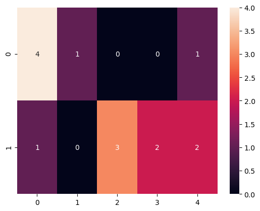

```python
df2 = np.random.randint(5,size=(2,5))
print(df2)
sb.heatmap(df2,annot=True)
plt.show()
```

# Tips Dataset

```python
tips = sb.load_dataset("tips")
tips.head()
```

|  | total_bill | tip | sex | smoker | day | time | size |
| --- | --- | --- | --- | --- | --- | --- | --- |
| 0 | 16.99 | 1.01 | Female | No | Sun | Dinner | 2 |
| 1 | 10.34 | 1.66 | Male | No | Sun | Dinner | 3 |
| 2 | 21.01 | 3.50 | Male | No | Sun | Dinner | 3 |
| 3 | 23.68 | 3.31 | Male | No | Sun | Dinner | 2 |
| 4 | 24.59 | 3.61 | Female | No | Sun | Dinner | 4 |

## Relational plot showing the relation between total bill and tipped amount

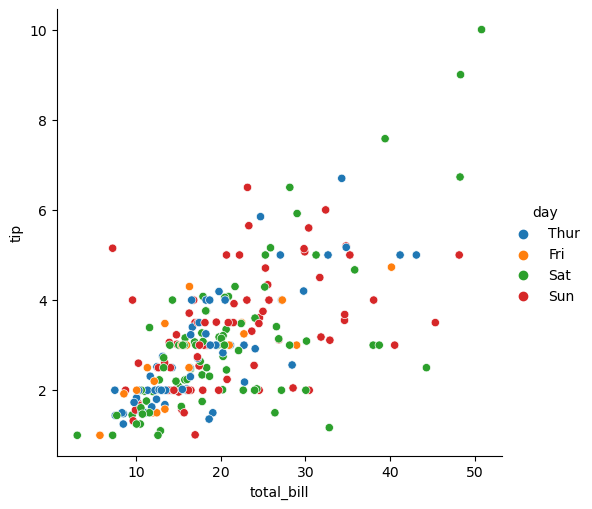

```python
sb.relplot(data=tips, x="total_bill", y="tip", hue="day")
plt.show()
```

## Same plot subsets based on time

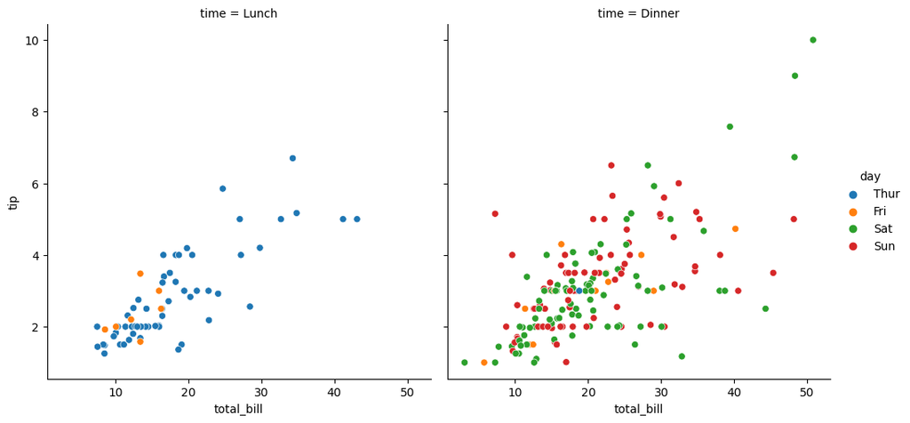

[figure not shown]

```python
sb.relplot(data=tips, x="total_bill", y="tip", hue="day", col="time")
plt.show()
```

## Same plot but subsets made from Sex and Time

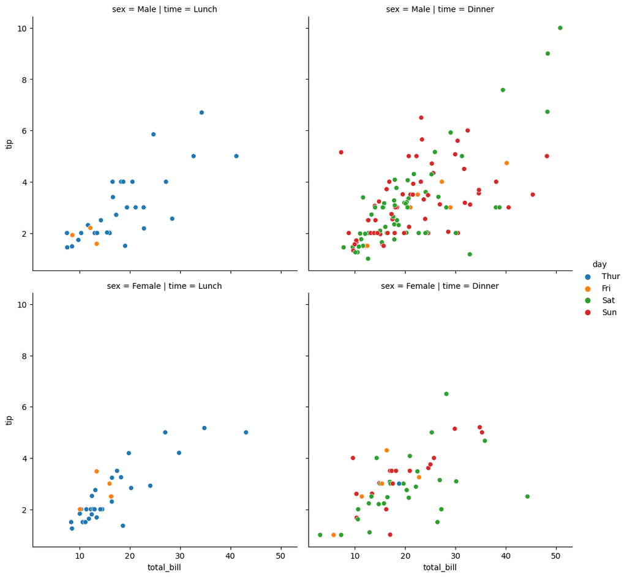

```python
sb.relplot(data=tips, x="total_bill", y="tip", hue="day", col="time", row="sex")
plt.show()
```

col_wrap indicates how many columns are to be shown in a row.

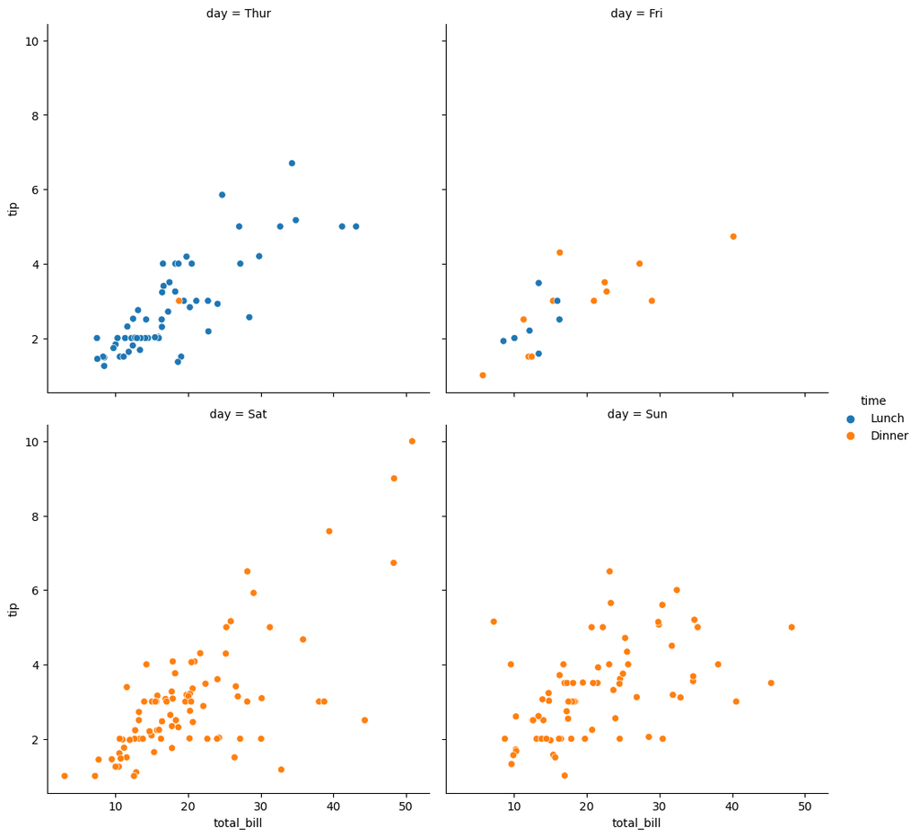

```python
sb.relplot(data=tips, x="total_bill", y="tip", hue="time", col="day", col_wrap=2)
plt.show()
```

## Categorical Plot

This function provides access to several axes-level functions that show the relationship between a numerical and one or more categorical variables using one of several visual representations.

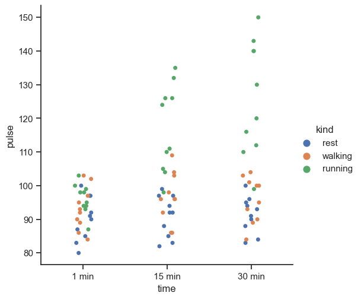

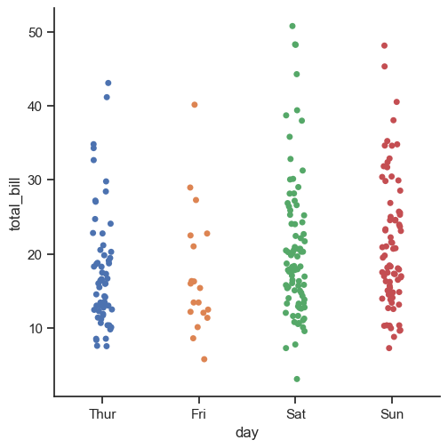

[figure not shown]

[figure not shown]

```python
sb.set_theme(style="ticks")
exercise = sb.load_dataset("exercise")
g = sb.catplot(x="time", y="pulse", hue="kind", data=exercise)

tips = sb.load_dataset("tips")
sb.catplot(x="day", y="total_bill", data=tips)
plt.show()
```

### Prevent points from overlapping

The second approach adjusts the points along the categorical axis using an algorithm that prevents them from overlapping. It can give a better representation of the distribution of observations, although it only works well for relatively small datasets. This kind of plot is sometimes called a “beeswarm” and is drawn in seaborn by swarmplot(), which is activated by setting kind="swarm" in catplot():

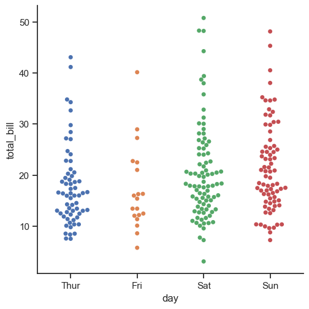

[figure not shown]

```python
sb.catplot(x="day", y="total_bill", kind="swarm", data=tips)
plt.show()
```

### Adding another dimension to display

Similar to the relational plots, it’s possible to add another dimension to a categorical plot by using a hue semantic. (The categorical plots do not currently support size or style semantics). Each different categorical plotting function handles the hue semantic differently. For the scatter plots, it is only necessary to change the color of the points:

```python
sb.catplot(x="day", y="total_bill", hue="sex", kind="swarm", data=tips)
plt.show()
```

[output not shown]

```python
sb.catplot(x="day", y="total_bill", hue="sex", kind="swarm", data=tips)
plt.show()
```

[output not shown]

```python
sb.catplot(x="day", y="total_bill", hue="sex", kind="swarm", data=tips)
plt.show()
```

[output not shown]

### Smoker vs Tip

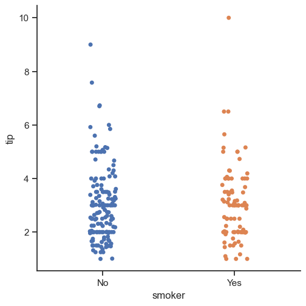

```python
sb.catplot(x="smoker", y="tip", order=["No", "Yes"], data=tips)
plt.show()
```

### Total bill vs Day

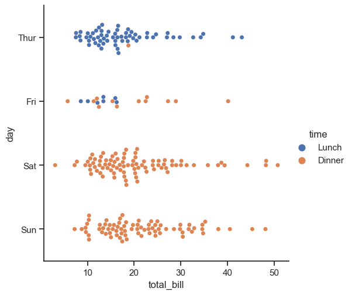

```python
sb.catplot(x="total_bill", y="day", hue="time", kind="swarm", data=tips)
plt.show()
```

## BoxPlot

Box Plot is the visual representation of the depicting groups of numerical data through their quartiles. A box plot consist of 5 things.

Minimum First Quartile or 25% Median (Second Quartile) or 50% Third Quartile or 75% Maximum

Bottom black horizontal line of blue box plot is minimum value First black horizontal line of rectangle shape of blue box plot is First quartile or 25% Second black horizontal line of rectangle shape of blue box plot is Second quartile or 50% or median. Third black horizontal line of rectangle shape of blue box plot is third quartile or 75% Top black horizontal line of rectangle shape of blue box plot is maximum value. Small diamond shape of blue box plot is outlier data or erroneous data.

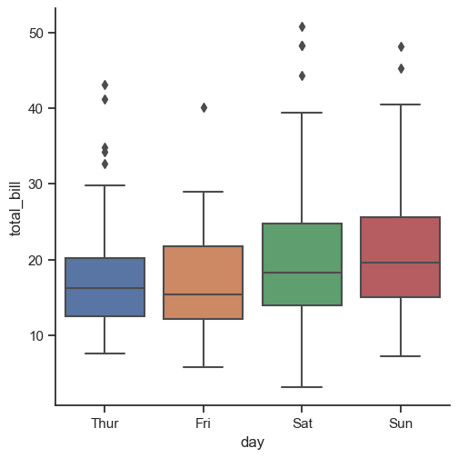

```python
sb.catplot(x="day", y="total_bill", kind="box", data=tips)
plt.show()
```

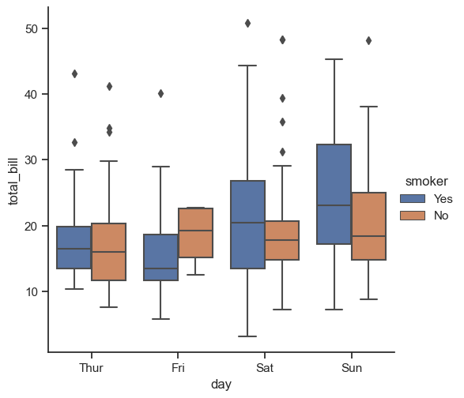

[figure not shown]

```python
sb.catplot(x="day", y="total_bill", hue="smoker", kind="box", data=tips)
plt.show()
```

## BarPlots

A familiar style of plot that accomplishes this goal is a bar plot. In seaborn, the barplot() function operates on a full dataset and applies a function to obtain the estimate (taking the mean by default). When there are multiple observations in each category, it also uses bootstrapping to compute a confidence interval around the estimate, which is plotted using error bars:

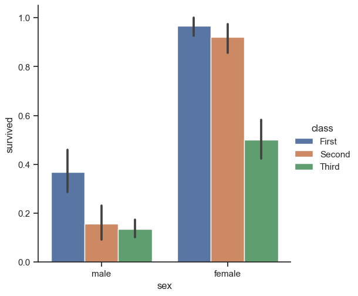

```python
titanic = sb.load_dataset("titanic")
sb.catplot(x="sex", y="survived", hue="class", kind="bar", data=titanic)
plt.show()
```

## Point Plots (Type of Categorical plot)

An alternative style for visualizing the same information is offered by the pointplot() function. This function also encodes the value of the estimate with height on the other axis, but rather than showing a full bar, it plots the point estimate and confidence interval.

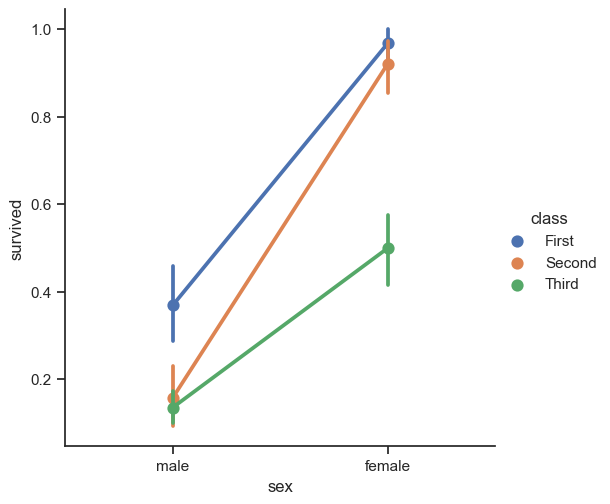

```python
sb.catplot(x="sex", y="survived", hue="class", kind="point", data=titanic)
plt.show()
```

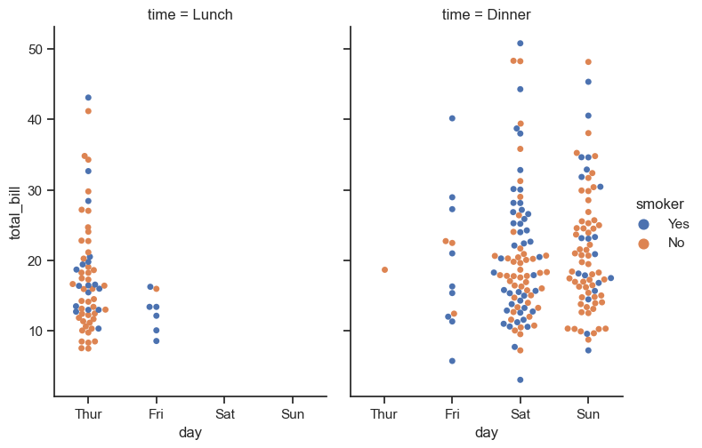

```python
sb.catplot(x="day", y="total_bill", hue="smoker",col="time",aspect=.7, kind="swarm", data=tips)
plt.show()
```

## Visualizing Distributions of Data

One example of a situation where defaults fail is when the variable takes a relatively small number of integer values. In that case, the default bin width may be too small, creating awkward gaps in the distribution:

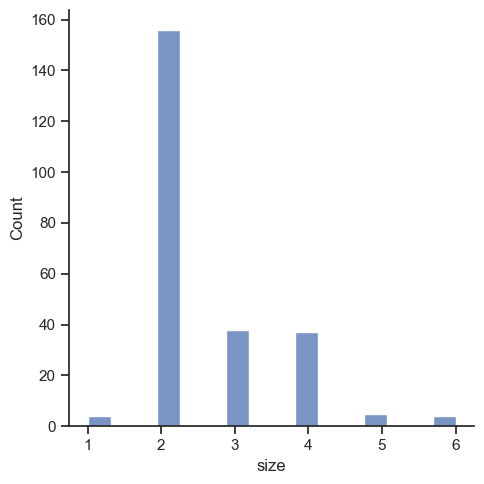

```python
tips = sb.load_dataset("tips")
sb.displot(tips, x="size")
plt.show()
```

One approach would be to specify the precise bin breaks by passing an array to bins:

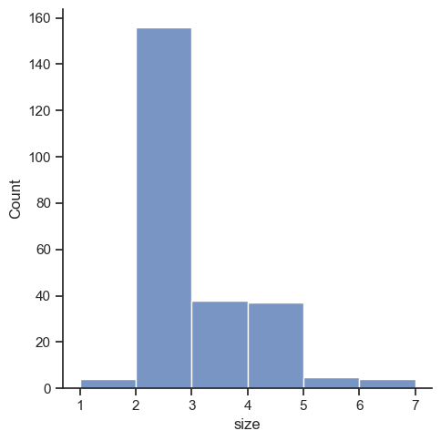

```python
sb.displot(tips, x="size", bins=[1, 2, 3, 4, 5, 6, 7])
plt.show()
```

This can also be accomplished by setting discrete=True, which chooses bin breaks that represent the unique values in a dataset with bars that are centered on their corresponding value.

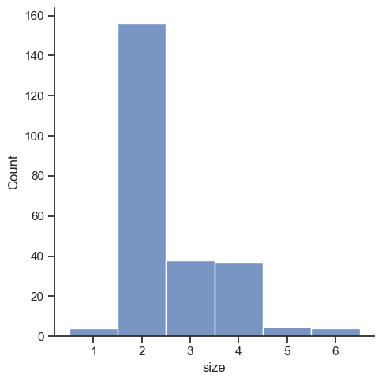

```python
sb.displot(tips, x="size", discrete=True)
plt.show()
```

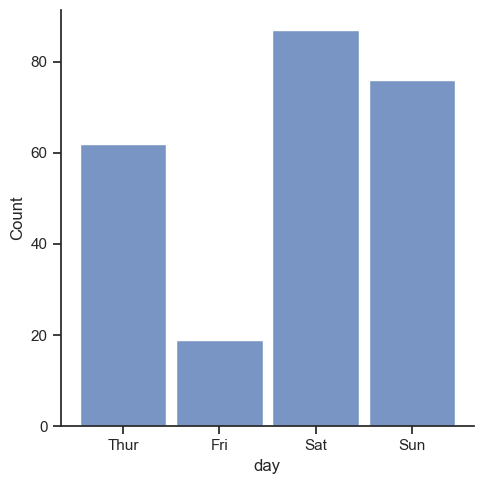

```python
sb.displot(tips, x="day", shrink=.90)
plt.show()
```

### Conditioning on other variables

Once you understand the distribution of a variable, the next step is often to ask whether features of that distribution differ across other variables in the dataset.

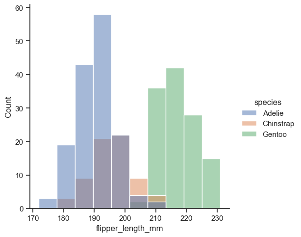

```python
penguins=sb.load_dataset("penguins")
sb.displot(penguins, x="flipper_length_mm", hue="species")
plt.show()
```

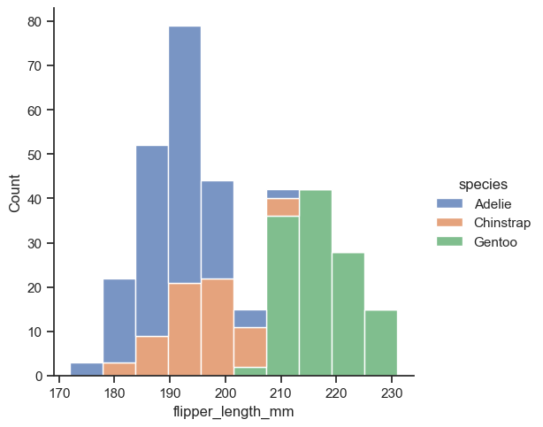

```python
sb.displot(penguins, x="flipper_length_mm", hue="species", multiple="stack")
plt.show()
```

## Visualizing bivariate distributions

All of the examples so far have considered univariate distributions: distributions of a single variable, perhaps conditional on a second variable assigned to hue. Assigning a second variable to y, however, will plot a bivariate distribution:

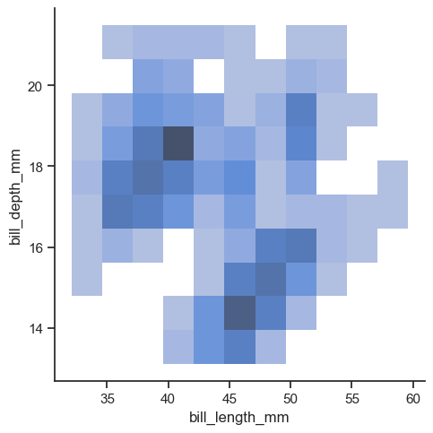

```python
sb.displot(penguins, x="bill_length_mm", y="bill_depth_mm")
plt.show()
```

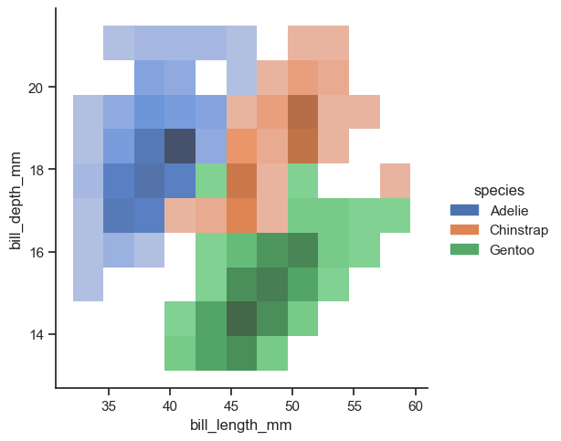

```python
sb.displot(penguins, x="bill_length_mm", y="bill_depth_mm", hue="species")
plt.show()
```